# scikit

Made by : Mohamed Osama Mostafa mohamed1996osama@gmail.com Amr Galal amrgalal7@yahoo.com Mahmoud Ahmed Selim mahmoudahmedselim96@gmail.com Khaled Issa khaled.ielmt@hotmail.com

```python
%matplotlib inline
import matplotlib.pyplot as plt
import cv2
```

## K-nearest neighbors (KNN) classification

1. Pick a value for K.
2. Search for the K observations in the training data that are "nearest" to the measurements of the unknown iris.
3. Use the most popular response value from the K nearest neighbors as the predicted response value for the unknown iris.

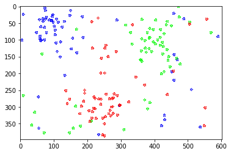

```python
training_data = cv2.imread("04_knn_dataset.png",1)
imgplot = plt.imshow(training_data)
```

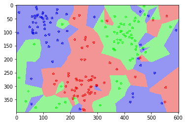

```python
k1 = cv2.imread("04_1nn_map.png",1)
imgplot = plt.imshow(k1)
```

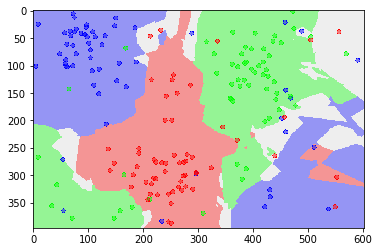

```python
k5 = cv2.imread("04_5nn_map.png",1)
imgplot = plt.imshow(k5)
```

## Introducing the iris dataset

-50 samples of 3 different species of iris (150 samples total) -Measurements: sepal length, sepal width, petal length, petal width

- **label** variable is the iris species
- **Classification** problem since response is categorical

## Loading the iris dataset into scikit-learn

```python
# import load_iris function from datasets module
import numpy as np
from sklearn.datasets import load_iris

# save "bunch" object containing iris dataset and its attributes
iris = load_iris()
# store feature matrix in "X"
X = iris.data

# store response vector in "y"
y = iris.target
print(np.shape(X))
```

```
(150, 4)
```

```python
print(np.shape(y))
```

```
(150,)
```

1. Split the dataset into two pieces: a **training set** and a **testing set**.
2. Train the model on the **training set**.
3. Test the model on the **testing set**, and evaluate how well we did.

```python
#split X and y into training and testing sets
from sklearn.model_selection import train_test_split
X_train, X_test, y_train, y_test = train_test_split(X, y, test_size=0.4, random_state=4)
```

```python
# print the shapes of the new X objects
print(X_train.shape)
print(X_test.shape)
```

```
(90, 4)
(60, 4)
```

```python
# print the shapes of the new y objects
print(y_train.shape)
print(y_test.shape)
```

```
(90,)
(60,)
```

**Step 1:** Import the class you plan to use

```python
from sklearn.neighbors import KNeighborsClassifier
```

**Step 2:** "Instantiate" the "model"

```python
knn = KNeighborsClassifier(n_neighbors=5)
```

**Step 3:** Fit the model with data "model training"

```python
knn.fit(X_train,y_train)
```

```
KNeighborsClassifier(algorithm='auto', leaf_size=30, metric='minkowski',
           metric_params=None, n_jobs=None, n_neighbors=5, p=2,
           weights='uniform')
```

**Step 4:** test model on test data"

```python
y_pred = knn.predict(X_test)
```

**Step 5:** accuracy"

```python
from sklearn import metrics
print(metrics.accuracy_score(y_test, y_pred))
```

```
0.9666666666666667
```

Repeat for KNN with K=1:

```python
knn=KNeighborsClassifier(n_neighbors=1)
knn.fit(X_train,y_train)
y_pred=knn.predict(X_test)
print(metrics.accuracy_score(y_test,y_pred))
```

```
0.95
```

- using logistic regression.
- "liblinear" is optmizer

```python
from sklearn.linear_model import LogisticRegression
logis=LogisticRegression(multi_class="auto",solver="liblinear")
logis.fit(X_train,y_train)
y_pred=logis.predict(X_test)
print(metrics.accuracy_score(y_test,y_pred))
```

```
0.9333333333333333
```